# Risk Factor Analysis

## Outcome Variable

**Outcome Variable:** swasted

## Predictor Variables

**Intervention Variable:** birthlen

**Adjustment Set:**

- arm
- sex
- W_mage
- meducyrs
- feducyrs
- vagbrth
- single
- brthmon
- W_parity
- delta_W_mage
- delta_meducyrs
- delta_feducyrs
- delta_vagbrth
- delta_single
- delta_brthmon
- delta_W_parity

## Stratifying Variables

The analysis was stratified on these variable(s):

- agecat
- studyid
- country

## Data Summary

| agecat | studyid | country | birthlen | swasted | n_cell | n |
| --- | --- | --- | --- | --- | --- | --- |
| Birth | ki0047075b-MAL-ED | BANGLADESH | >=50 cm | 0 | 25 | 241 |
| Birth | ki0047075b-MAL-ED | BANGLADESH | >=50 cm | 1 | 4 | 241 |
| Birth | ki0047075b-MAL-ED | BANGLADESH | <48 cm | 0 | 126 | 241 |
| Birth | ki0047075b-MAL-ED | BANGLADESH | <48 cm | 1 | 2 | 241 |
| Birth | ki0047075b-MAL-ED | BANGLADESH | [48-50) cm | 0 | 82 | 241 |
| Birth | ki0047075b-MAL-ED | BANGLADESH | [48-50) cm | 1 | 2 | 241 |
| Birth | ki0047075b-MAL-ED | BRAZIL | >=50 cm | 0 | 34 | 183 |
| Birth | ki0047075b-MAL-ED | BRAZIL | >=50 cm | 1 | 0 | 183 |
| Birth | ki0047075b-MAL-ED | BRAZIL | <48 cm | 0 | 73 | 183 |
| Birth | ki0047075b-MAL-ED | BRAZIL | <48 cm | 1 | 0 | 183 |
| Birth | ki0047075b-MAL-ED | BRAZIL | [48-50) cm | 0 | 76 | 183 |
| Birth | ki0047075b-MAL-ED | BRAZIL | [48-50) cm | 1 | 0 | 183 |
| Birth | ki0047075b-MAL-ED | INDIA | >=50 cm | 0 | 25 | 203 |
| Birth | ki0047075b-MAL-ED | INDIA | >=50 cm | 1 | 0 | 203 |
| Birth | ki0047075b-MAL-ED | INDIA | <48 cm | 0 | 98 | 203 |
| Birth | ki0047075b-MAL-ED | INDIA | <48 cm | 1 | 6 | 203 |
| Birth | ki0047075b-MAL-ED | INDIA | [48-50) cm | 0 | 73 | 203 |
| Birth | ki0047075b-MAL-ED | INDIA | [48-50) cm | 1 | 1 | 203 |
| Birth | ki0047075b-MAL-ED | NEPAL | >=50 cm | 0 | 36 | 168 |
| Birth | ki0047075b-MAL-ED | NEPAL | >=50 cm | 1 | 2 | 168 |
| Birth | ki0047075b-MAL-ED | NEPAL | <48 cm | 0 | 62 | 168 |
| Birth | ki0047075b-MAL-ED | NEPAL | <48 cm | 1 | 2 | 168 |
| Birth | ki0047075b-MAL-ED | NEPAL | [48-50) cm | 0 | 66 | 168 |
| Birth | ki0047075b-MAL-ED | NEPAL | [48-50) cm | 1 | 0 | 168 |
| Birth | ki0047075b-MAL-ED | PERU | >=50 cm | 0 | 34 | 279 |
| Birth | ki0047075b-MAL-ED | PERU | >=50 cm | 1 | 0 | 279 |
| Birth | ki0047075b-MAL-ED | PERU | <48 cm | 0 | 134 | 279 |
| Birth | ki0047075b-MAL-ED | PERU | <48 cm | 1 | 0 | 279 |
| Birth | ki0047075b-MAL-ED | PERU | [48-50) cm | 0 | 111 | 279 |
| Birth | ki0047075b-MAL-ED | PERU | [48-50) cm | 1 | 0 | 279 |

[output cut: 432 more lines]

The following strata were considered:

- agecat: 24 months, studyid: ki0047075b-MAL-ED, country: BANGLADESH
- agecat: 24 months, studyid: ki0047075b-MAL-ED, country: BRAZIL
- agecat: 24 months, studyid: ki0047075b-MAL-ED, country: INDIA
- agecat: 24 months, studyid: ki0047075b-MAL-ED, country: NEPAL
- agecat: 24 months, studyid: ki0047075b-MAL-ED, country: PERU
- agecat: 24 months, studyid: ki0047075b-MAL-ED, country: SOUTH AFRICA
- agecat: 24 months, studyid: ki0047075b-MAL-ED, country: TANZANIA, UNITED REPUBLIC OF
- agecat: 24 months, studyid: ki1000108-CMC-V-BCS-2002, country: INDIA
- agecat: 24 months, studyid: ki1000108-IRC, country: INDIA
- agecat: 24 months, studyid: ki1017093-NIH-Birth, country: BANGLADESH
- agecat: 24 months, studyid: ki1017093b-PROVIDE, country: BANGLADESH
- agecat: 24 months, studyid: ki1017093c-NIH-Crypto, country: BANGLADESH
- agecat: 24 months, studyid: ki1101329-Keneba, country: GAMBIA
- agecat: 24 months, studyid: ki1114097-CMIN, country: BANGLADESH
- agecat: 24 months, studyid: ki1114097-CMIN, country: PERU
- agecat: 24 months, studyid: ki1114097-CONTENT, country: PERU
- agecat: 24 months, studyid: ki1119695-PROBIT, country: BELARUS
- agecat: 24 months, studyid: ki1126311-ZVITAMBO, country: ZIMBABWE
- agecat: 24 months, studyid: ki1135781-COHORTS, country: GUATEMALA
- agecat: 24 months, studyid: ki1135781-COHORTS, country: INDIA
- agecat: 24 months, studyid: ki1135781-COHORTS, country: PHILIPPINES
- agecat: 24 months, studyid: kiGH5241-JiVitA-3, country: BANGLADESH
- agecat: 24 months, studyid: kiGH5241-JiVitA-4, country: BANGLADESH
- agecat: 6 months, studyid: ki0047075b-MAL-ED, country: BANGLADESH
- agecat: 6 months, studyid: ki0047075b-MAL-ED, country: BRAZIL
- agecat: 6 months, studyid: ki0047075b-MAL-ED, country: INDIA
- agecat: 6 months, studyid: ki0047075b-MAL-ED, country: NEPAL
- agecat: 6 months, studyid: ki0047075b-MAL-ED, country: PERU
- agecat: 6 months, studyid: ki0047075b-MAL-ED, country: SOUTH AFRICA
- agecat: 6 months, studyid: ki0047075b-MAL-ED, country: TANZANIA, UNITED REPUBLIC OF
- agecat: 6 months, studyid: ki1000108-CMC-V-BCS-2002, country: INDIA
- agecat: 6 months, studyid: ki1000108-IRC, country: INDIA
- agecat: 6 months, studyid: ki1000109-EE, country: PAKISTAN
- agecat: 6 months, studyid: ki1000109-ResPak, country: PAKISTAN
- agecat: 6 months, studyid: ki1000304b-SAS-CompFeed, country: INDIA
- agecat: 6 months, studyid: ki1017093-NIH-Birth, country: BANGLADESH
- agecat: 6 months, studyid: ki1017093b-PROVIDE, country: BANGLADESH
- agecat: 6 months, studyid: ki1017093c-NIH-Crypto, country: BANGLADESH
- agecat: 6 months, studyid: ki1101329-Keneba, country: GAMBIA
- agecat: 6 months, studyid: ki1114097-CMIN, country: BANGLADESH
- agecat: 6 months, studyid: ki1114097-CMIN, country: BRAZIL
- agecat: 6 months, studyid: ki1114097-CMIN, country: GUINEA-BISSAU
- agecat: 6 months, studyid: ki1114097-CMIN, country: PERU
- agecat: 6 months, studyid: ki1114097-CONTENT, country: PERU
- agecat: 6 months, studyid: ki1119695-PROBIT, country: BELARUS
- agecat: 6 months, studyid: ki1126311-ZVITAMBO, country: ZIMBABWE
- agecat: 6 months, studyid: ki1135781-COHORTS, country: GUATEMALA
- agecat: 6 months, studyid: ki1135781-COHORTS, country: INDIA
- agecat: 6 months, studyid: ki1135781-COHORTS, country: PHILIPPINES
- agecat: 6 months, studyid: kiGH5241-JiVitA-3, country: BANGLADESH
- agecat: 6 months, studyid: kiGH5241-JiVitA-4, country: BANGLADESH
- agecat: Birth, studyid: ki0047075b-MAL-ED, country: BANGLADESH
- agecat: Birth, studyid: ki0047075b-MAL-ED, country: BRAZIL
- agecat: Birth, studyid: ki0047075b-MAL-ED, country: INDIA
- agecat: Birth, studyid: ki0047075b-MAL-ED, country: NEPAL
- agecat: Birth, studyid: ki0047075b-MAL-ED, country: PERU
- agecat: Birth, studyid: ki0047075b-MAL-ED, country: SOUTH AFRICA
- agecat: Birth, studyid: ki0047075b-MAL-ED, country: TANZANIA, UNITED REPUBLIC OF
- agecat: Birth, studyid: ki1000108-CMC-V-BCS-2002, country: INDIA
- agecat: Birth, studyid: ki1000108-IRC, country: INDIA
- agecat: Birth, studyid: ki1000109-EE, country: PAKISTAN
- agecat: Birth, studyid: ki1000109-ResPak, country: PAKISTAN
- agecat: Birth, studyid: ki1000304b-SAS-CompFeed, country: INDIA
- agecat: Birth, studyid: ki1017093-NIH-Birth, country: BANGLADESH
- agecat: Birth, studyid: ki1017093c-NIH-Crypto, country: BANGLADESH
- agecat: Birth, studyid: ki1101329-Keneba, country: GAMBIA
- agecat: Birth, studyid: ki1114097-CMIN, country: BANGLADESH
- agecat: Birth, studyid: ki1114097-CMIN, country: BRAZIL
- agecat: Birth, studyid: ki1114097-CMIN, country: PERU
- agecat: Birth, studyid: ki1114097-CONTENT, country: PERU
- agecat: Birth, studyid: ki1119695-PROBIT, country: BELARUS
- agecat: Birth, studyid: ki1126311-ZVITAMBO, country: ZIMBABWE
- agecat: Birth, studyid: ki1135781-COHORTS, country: GUATEMALA
- agecat: Birth, studyid: ki1135781-COHORTS, country: INDIA
- agecat: Birth, studyid: ki1135781-COHORTS, country: PHILIPPINES
- agecat: Birth, studyid: kiGH5241-JiVitA-3, country: BANGLADESH
- agecat: Birth, studyid: kiGH5241-JiVitA-4, country: BANGLADESH

### Dropped Strata

Some strata were dropped due to rare outcomes:

- agecat: Birth, studyid: ki0047075b-MAL-ED, country: BANGLADESH
- agecat: Birth, studyid: ki0047075b-MAL-ED, country: BRAZIL
- agecat: Birth, studyid: ki0047075b-MAL-ED, country: INDIA
- agecat: Birth, studyid: ki0047075b-MAL-ED, country: NEPAL
- agecat: Birth, studyid: ki0047075b-MAL-ED, country: PERU
- agecat: Birth, studyid: ki0047075b-MAL-ED, country: SOUTH AFRICA
- agecat: Birth, studyid: ki0047075b-MAL-ED, country: TANZANIA, UNITED REPUBLIC OF
- agecat: Birth, studyid: ki1000108-CMC-V-BCS-2002, country: INDIA
- agecat: Birth, studyid: ki1000109-EE, country: PAKISTAN
- agecat: Birth, studyid: ki1000109-ResPak, country: PAKISTAN
- agecat: Birth, studyid: ki1000304b-SAS-CompFeed, country: INDIA
- agecat: Birth, studyid: ki1017093-NIH-Birth, country: BANGLADESH
- agecat: Birth, studyid: ki1017093c-NIH-Crypto, country: BANGLADESH
- agecat: Birth, studyid: ki1101329-Keneba, country: GAMBIA
- agecat: Birth, studyid: ki1114097-CMIN, country: BANGLADESH
- agecat: Birth, studyid: ki1114097-CMIN, country: BRAZIL
- agecat: Birth, studyid: ki1114097-CMIN, country: PERU
- agecat: Birth, studyid: ki1114097-CONTENT, country: PERU
- agecat: Birth, studyid: ki1119695-PROBIT, country: BELARUS
- agecat: Birth, studyid: ki1135781-COHORTS, country: GUATEMALA
- agecat: Birth, studyid: kiGH5241-JiVitA-4, country: BANGLADESH
- agecat: 6 months, studyid: ki0047075b-MAL-ED, country: BANGLADESH
- agecat: 6 months, studyid: ki0047075b-MAL-ED, country: BRAZIL
- agecat: 6 months, studyid: ki0047075b-MAL-ED, country: INDIA
- agecat: 6 months, studyid: ki0047075b-MAL-ED, country: NEPAL
- agecat: 6 months, studyid: ki0047075b-MAL-ED, country: PERU
- agecat: 6 months, studyid: ki0047075b-MAL-ED, country: SOUTH AFRICA
- agecat: 6 months, studyid: ki0047075b-MAL-ED, country: TANZANIA, UNITED REPUBLIC OF
- agecat: 6 months, studyid: ki1000108-CMC-V-BCS-2002, country: INDIA
- agecat: 6 months, studyid: ki1000108-IRC, country: INDIA
- agecat: 6 months, studyid: ki1000109-EE, country: PAKISTAN
- agecat: 6 months, studyid: ki1000109-ResPak, country: PAKISTAN
- agecat: 6 months, studyid: ki1000304b-SAS-CompFeed, country: INDIA
- agecat: 6 months, studyid: ki1017093-NIH-Birth, country: BANGLADESH
- agecat: 6 months, studyid: ki1017093b-PROVIDE, country: BANGLADESH
- agecat: 6 months, studyid: ki1017093c-NIH-Crypto, country: BANGLADESH
- agecat: 6 months, studyid: ki1101329-Keneba, country: GAMBIA
- agecat: 6 months, studyid: ki1114097-CMIN, country: BANGLADESH
- agecat: 6 months, studyid: ki1114097-CMIN, country: BRAZIL
- agecat: 6 months, studyid: ki1114097-CMIN, country: GUINEA-BISSAU
- agecat: 6 months, studyid: ki1114097-CMIN, country: PERU
- agecat: 6 months, studyid: ki1114097-CONTENT, country: PERU
- agecat: 6 months, studyid: ki1119695-PROBIT, country: BELARUS
- agecat: 6 months, studyid: ki1135781-COHORTS, country: GUATEMALA
- agecat: 6 months, studyid: kiGH5241-JiVitA-4, country: BANGLADESH
- agecat: 24 months, studyid: ki0047075b-MAL-ED, country: BANGLADESH
- agecat: 24 months, studyid: ki0047075b-MAL-ED, country: BRAZIL
- agecat: 24 months, studyid: ki0047075b-MAL-ED, country: INDIA
- agecat: 24 months, studyid: ki0047075b-MAL-ED, country: NEPAL
- agecat: 24 months, studyid: ki0047075b-MAL-ED, country: PERU
- agecat: 24 months, studyid: ki0047075b-MAL-ED, country: SOUTH AFRICA
- agecat: 24 months, studyid: ki0047075b-MAL-ED, country: TANZANIA, UNITED REPUBLIC OF
- agecat: 24 months, studyid: ki1000108-CMC-V-BCS-2002, country: INDIA
- agecat: 24 months, studyid: ki1000108-IRC, country: INDIA
- agecat: 24 months, studyid: ki1017093-NIH-Birth, country: BANGLADESH
- agecat: 24 months, studyid: ki1017093b-PROVIDE, country: BANGLADESH
- agecat: 24 months, studyid: ki1017093c-NIH-Crypto, country: BANGLADESH
- agecat: 24 months, studyid: ki1114097-CMIN, country: BANGLADESH
- agecat: 24 months, studyid: ki1114097-CMIN, country: PERU
- agecat: 24 months, studyid: ki1114097-CONTENT, country: PERU
- agecat: 24 months, studyid: ki1119695-PROBIT, country: BELARUS
- agecat: 24 months, studyid: ki1126311-ZVITAMBO, country: ZIMBABWE
- agecat: 24 months, studyid: ki1135781-COHORTS, country: GUATEMALA
- agecat: 24 months, studyid: ki1135781-COHORTS, country: PHILIPPINES

## Methods Detail

We’re interested in the causal parameters $E[Y_a]$ for all values of $a \in \mathcal{A}$. These parameters represent the mean outcome if, possibly contrary to fact, we intervened to set all units to have $A=a$. Under the randomization and positivity assumptions, these are identified by the statistical parameters $\psi_a=E_W[E_{Y|A,W}(Y|A=a,W)]$. In addition, we’re interested in the mean of $Y$, $E[Y]$ under no intervention (the observed mean). We will estimate these parameters by using SuperLearner to fit the relevant likelihood factors – $E_{Y|A,W}(Y|A=a,W)$ and $p(A=a|W)$, and then updating our likelihood fit using a joint TMLE.

For unadjusted analyses ($W=\{\}$), initial likelihoods were estimated using Lrnr_glm to estimate the simple $E(Y|A)$ and Lrnr_mean to estimate $p(A)$. For adjusted analyses, a small library containing Lrnr_glmnet, Lrnr_xgboost, and Lrnr_mean was used.

Having estimated these parameters, we will then use the delta method to estimate relative risks and attributable risks relative to a prespecified baseline level of $A$.

# Results Detail

## Results Plots

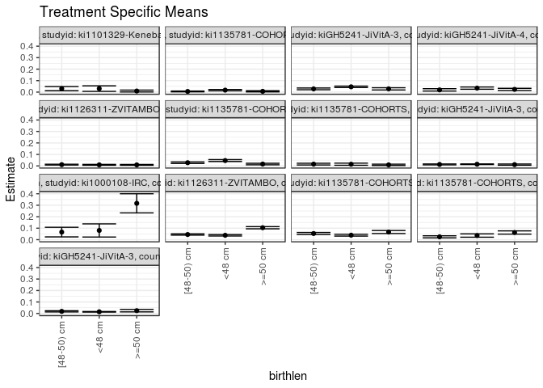

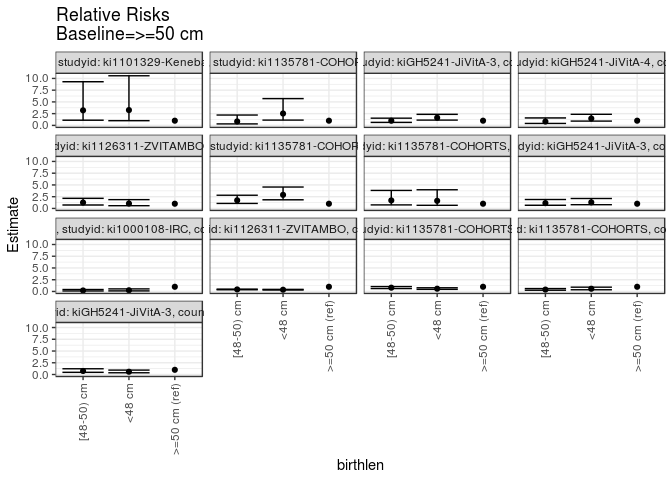

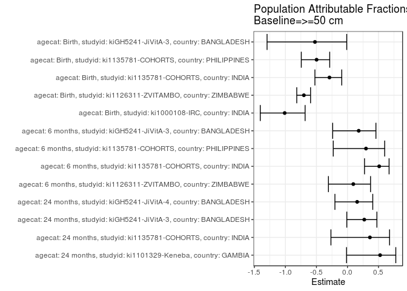

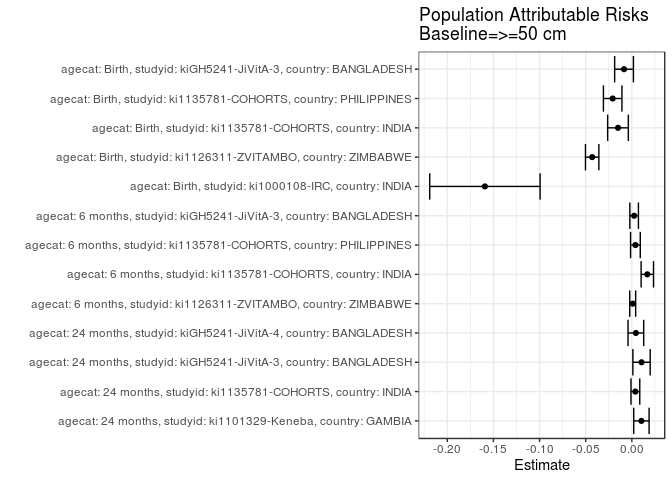

## Results Table

### Parameter: TSM

| agecat | studyid | country | intervention_level | baseline_level | estimate | ci_lower | ci_upper |
| --- | --- | --- | --- | --- | --- | --- | --- |
| Birth | ki1000108-IRC | INDIA | >=50 cm | NA | 0.3166667 | 0.2333160 | 0.4000173 |
| Birth | ki1000108-IRC | INDIA | <48 cm | NA | 0.0804598 | 0.0232201 | 0.1376995 |
| Birth | ki1000108-IRC | INDIA | [48-50) cm | NA | 0.0661765 | 0.0243360 | 0.1080170 |
| Birth | ki1126311-ZVITAMBO | ZIMBABWE | >=50 cm | NA | 0.1042418 | 0.0947232 | 0.1137604 |
| Birth | ki1126311-ZVITAMBO | ZIMBABWE | <48 cm | NA | 0.0383497 | 0.0320816 | 0.0446179 |
| Birth | ki1126311-ZVITAMBO | ZIMBABWE | [48-50) cm | NA | 0.0450032 | 0.0393846 | 0.0506219 |
| Birth | ki1135781-COHORTS | INDIA | >=50 cm | NA | 0.0666728 | 0.0535661 | 0.0797794 |
| Birth | ki1135781-COHORTS | INDIA | <48 cm | NA | 0.0392379 | 0.0313819 | 0.0470938 |
| Birth | ki1135781-COHORTS | INDIA | [48-50) cm | NA | 0.0536628 | 0.0446243 | 0.0627014 |
| Birth | ki1135781-COHORTS | PHILIPPINES | >=50 cm | NA | 0.0625058 | 0.0483410 | 0.0766707 |
| Birth | ki1135781-COHORTS | PHILIPPINES | <48 cm | NA | 0.0361887 | 0.0218221 | 0.0505552 |
| Birth | ki1135781-COHORTS | PHILIPPINES | [48-50) cm | NA | 0.0248511 | 0.0158153 | 0.0338869 |
| Birth | kiGH5241-JiVitA-3 | BANGLADESH | >=50 cm | NA | 0.0246409 | 0.0139124 | 0.0353694 |
| Birth | kiGH5241-JiVitA-3 | BANGLADESH | <48 cm | NA | 0.0145556 | 0.0120945 | 0.0170167 |
| Birth | kiGH5241-JiVitA-3 | BANGLADESH | [48-50) cm | NA | 0.0184783 | 0.0135318 | 0.0234248 |
| 6 months | ki1126311-ZVITAMBO | ZIMBABWE | >=50 cm | NA | 0.0087572 | 0.0050182 | 0.0124962 |
| 6 months | ki1126311-ZVITAMBO | ZIMBABWE | <48 cm | NA | 0.0091152 | 0.0054545 | 0.0127759 |
| 6 months | ki1126311-ZVITAMBO | ZIMBABWE | [48-50) cm | NA | 0.0109626 | 0.0073221 | 0.0146031 |
| 6 months | ki1135781-COHORTS | INDIA | >=50 cm | NA | 0.0160482 | 0.0093440 | 0.0227524 |
| 6 months | ki1135781-COHORTS | INDIA | <48 cm | NA | 0.0463750 | 0.0381189 | 0.0546311 |
| 6 months | ki1135781-COHORTS | INDIA | [48-50) cm | NA | 0.0277003 | 0.0207527 | 0.0346479 |
| 6 months | ki1135781-COHORTS | PHILIPPINES | >=50 cm | NA | 0.0091001 | 0.0031808 | 0.0150194 |
| 6 months | ki1135781-COHORTS | PHILIPPINES | <48 cm | NA | 0.0147710 | 0.0056822 | 0.0238599 |
| 6 months | ki1135781-COHORTS | PHILIPPINES | [48-50) cm | NA | 0.0154889 | 0.0079571 | 0.0230207 |
| 6 months | kiGH5241-JiVitA-3 | BANGLADESH | >=50 cm | NA | 0.0112342 | 0.0062010 | 0.0162674 |
| 6 months | kiGH5241-JiVitA-3 | BANGLADESH | <48 cm | NA | 0.0145542 | 0.0117968 | 0.0173116 |
| 6 months | kiGH5241-JiVitA-3 | BANGLADESH | [48-50) cm | NA | 0.0126715 | 0.0087939 | 0.0165492 |
| 24 months | ki1101329-Keneba | GAMBIA | >=50 cm | NA | 0.0093458 | 0.0011885 | 0.0175031 |
| 24 months | ki1101329-Keneba | GAMBIA | <48 cm | NA | 0.0304569 | 0.0064495 | 0.0544642 |
| 24 months | ki1101329-Keneba | GAMBIA | [48-50) cm | NA | 0.0299401 | 0.0116547 | 0.0482255 |
| 24 months | ki1135781-COHORTS | INDIA | >=50 cm | NA | 0.0067633 | 0.0017695 | 0.0117571 |
| 24 months | ki1135781-COHORTS | INDIA | <48 cm | NA | 0.0171162 | 0.0113260 | 0.0229064 |
| 24 months | ki1135781-COHORTS | INDIA | [48-50) cm | NA | 0.0056850 | 0.0021711 | 0.0091990 |
| 24 months | kiGH5241-JiVitA-3 | BANGLADESH | >=50 cm | NA | 0.0282495 | 0.0186857 | 0.0378132 |
| 24 months | kiGH5241-JiVitA-3 | BANGLADESH | <48 cm | NA | 0.0460633 | 0.0399052 | 0.0522214 |
| 24 months | kiGH5241-JiVitA-3 | BANGLADESH | [48-50) cm | NA | 0.0279764 | 0.0203132 | 0.0356397 |
| 24 months | kiGH5241-JiVitA-4 | BANGLADESH | >=50 cm | NA | 0.0235809 | 0.0142742 | 0.0328876 |
| 24 months | kiGH5241-JiVitA-4 | BANGLADESH | <48 cm | NA | 0.0345763 | 0.0249328 | 0.0442198 |
| 24 months | kiGH5241-JiVitA-4 | BANGLADESH | [48-50) cm | NA | 0.0192881 | 0.0090629 | 0.0295133 |

### Parameter: E(Y)

| agecat | studyid | country | intervention_level | baseline_level | estimate | ci_lower | ci_upper |
| --- | --- | --- | --- | --- | --- | --- | --- |
| Birth | ki1000108-IRC | INDIA | NA | NA | 0.1574344 | 0.1188345 | 0.1960344 |
| Birth | ki1126311-ZVITAMBO | ZIMBABWE | NA | NA | 0.0612419 | 0.0571066 | 0.0653771 |
| Birth | ki1135781-COHORTS | INDIA | NA | NA | 0.0516712 | 0.0461576 | 0.0571849 |
| Birth | ki1135781-COHORTS | PHILIPPINES | NA | NA | 0.0417385 | 0.0344572 | 0.0490198 |
| Birth | kiGH5241-JiVitA-3 | BANGLADESH | NA | NA | 0.0161691 | 0.0138058 | 0.0185324 |
| 6 months | ki1126311-ZVITAMBO | ZIMBABWE | NA | NA | 0.0096636 | 0.0075428 | 0.0117844 |
| 6 months | ki1135781-COHORTS | INDIA | NA | NA | 0.0328056 | 0.0283450 | 0.0372662 |
| 6 months | ki1135781-COHORTS | PHILIPPINES | NA | NA | 0.0129678 | 0.0086988 | 0.0172368 |
| 6 months | kiGH5241-JiVitA-3 | BANGLADESH | NA | NA | 0.0137136 | 0.0115856 | 0.0158416 |
| 24 months | ki1101329-Keneba | GAMBIA | NA | NA | 0.0196998 | 0.0113537 | 0.0280459 |
| 24 months | ki1135781-COHORTS | INDIA | NA | NA | 0.0105887 | 0.0076690 | 0.0135085 |
| 24 months | kiGH5241-JiVitA-3 | BANGLADESH | NA | NA | 0.0387403 | 0.0343586 | 0.0431221 |
| 24 months | kiGH5241-JiVitA-4 | BANGLADESH | NA | NA | 0.0279316 | 0.0220494 | 0.0338137 |

### Parameter: RR

| agecat | studyid | country | intervention_level | baseline_level | estimate | ci_lower | ci_upper |
| --- | --- | --- | --- | --- | --- | --- | --- |
| Birth | ki1000108-IRC | INDIA | >=50 cm | >=50 cm | 1.0000000 | 1.0000000 | 1.0000000 |
| Birth | ki1000108-IRC | INDIA | <48 cm | >=50 cm | 0.2540835 | 0.1190000 | 0.5425075 |
| Birth | ki1000108-IRC | INDIA | [48-50) cm | >=50 cm | 0.2089783 | 0.1053590 | 0.4145060 |
| Birth | ki1126311-ZVITAMBO | ZIMBABWE | >=50 cm | >=50 cm | 1.0000000 | 1.0000000 | 1.0000000 |
| Birth | ki1126311-ZVITAMBO | ZIMBABWE | <48 cm | >=50 cm | 0.3678922 | 0.3050755 | 0.4436433 |
| Birth | ki1126311-ZVITAMBO | ZIMBABWE | [48-50) cm | >=50 cm | 0.4317197 | 0.3698628 | 0.5039219 |
| Birth | ki1135781-COHORTS | INDIA | >=50 cm | >=50 cm | 1.0000000 | 1.0000000 | 1.0000000 |
| Birth | ki1135781-COHORTS | INDIA | <48 cm | >=50 cm | 0.5885138 | 0.4445589 | 0.7790833 |
| Birth | ki1135781-COHORTS | INDIA | [48-50) cm | >=50 cm | 0.8048684 | 0.6213192 | 1.0426415 |
| Birth | ki1135781-COHORTS | PHILIPPINES | >=50 cm | >=50 cm | 1.0000000 | 1.0000000 | 1.0000000 |
| Birth | ki1135781-COHORTS | PHILIPPINES | <48 cm | >=50 cm | 0.5789652 | 0.3665984 | 0.9143537 |
| Birth | ki1135781-COHORTS | PHILIPPINES | [48-50) cm | >=50 cm | 0.3975804 | 0.2590812 | 0.6101181 |
| Birth | kiGH5241-JiVitA-3 | BANGLADESH | >=50 cm | >=50 cm | 1.0000000 | 1.0000000 | 1.0000000 |
| Birth | kiGH5241-JiVitA-3 | BANGLADESH | <48 cm | >=50 cm | 0.5907090 | 0.3713138 | 0.9397365 |
| Birth | kiGH5241-JiVitA-3 | BANGLADESH | [48-50) cm | >=50 cm | 0.7499045 | 0.4603492 | 1.2215875 |
| 6 months | ki1126311-ZVITAMBO | ZIMBABWE | >=50 cm | >=50 cm | 1.0000000 | 1.0000000 | 1.0000000 |
| 6 months | ki1126311-ZVITAMBO | ZIMBABWE | <48 cm | >=50 cm | 1.0408760 | 0.5792411 | 1.8704179 |
| 6 months | ki1126311-ZVITAMBO | ZIMBABWE | [48-50) cm | >=50 cm | 1.2518334 | 0.7288412 | 2.1501074 |
| 6 months | ki1135781-COHORTS | INDIA | >=50 cm | >=50 cm | 1.0000000 | 1.0000000 | 1.0000000 |
| 6 months | ki1135781-COHORTS | INDIA | <48 cm | >=50 cm | 2.8897343 | 1.8349943 | 4.5507303 |
| 6 months | ki1135781-COHORTS | INDIA | [48-50) cm | >=50 cm | 1.7260710 | 1.0603212 | 2.8098289 |
| 6 months | ki1135781-COHORTS | PHILIPPINES | >=50 cm | >=50 cm | 1.0000000 | 1.0000000 | 1.0000000 |
| 6 months | ki1135781-COHORTS | PHILIPPINES | <48 cm | >=50 cm | 1.6231741 | 0.6629864 | 3.9739795 |
| 6 months | ki1135781-COHORTS | PHILIPPINES | [48-50) cm | >=50 cm | 1.7020544 | 0.7555587 | 3.8342347 |
| 6 months | kiGH5241-JiVitA-3 | BANGLADESH | >=50 cm | >=50 cm | 1.0000000 | 1.0000000 | 1.0000000 |
| 6 months | kiGH5241-JiVitA-3 | BANGLADESH | <48 cm | >=50 cm | 1.2955282 | 0.7949126 | 2.1114186 |
| 6 months | kiGH5241-JiVitA-3 | BANGLADESH | [48-50) cm | >=50 cm | 1.1279462 | 0.6706683 | 1.8970070 |
| 24 months | ki1101329-Keneba | GAMBIA | >=50 cm | >=50 cm | 1.0000000 | 1.0000000 | 1.0000000 |
| 24 months | ki1101329-Keneba | GAMBIA | <48 cm | >=50 cm | 3.2588832 | 1.0053237 | 10.5640797 |
| 24 months | ki1101329-Keneba | GAMBIA | [48-50) cm | >=50 cm | 3.2035928 | 1.1040590 | 9.2957052 |
| 24 months | ki1135781-COHORTS | INDIA | >=50 cm | >=50 cm | 1.0000000 | 1.0000000 | 1.0000000 |
| 24 months | ki1135781-COHORTS | INDIA | <48 cm | >=50 cm | 2.5307499 | 1.1233819 | 5.7012625 |
| 24 months | ki1135781-COHORTS | INDIA | [48-50) cm | >=50 cm | 0.8405750 | 0.3209098 | 2.2017599 |
| 24 months | kiGH5241-JiVitA-3 | BANGLADESH | >=50 cm | >=50 cm | 1.0000000 | 1.0000000 | 1.0000000 |
| 24 months | kiGH5241-JiVitA-3 | BANGLADESH | <48 cm | >=50 cm | 1.6305904 | 1.1298110 | 2.3533363 |
| 24 months | kiGH5241-JiVitA-3 | BANGLADESH | [48-50) cm | >=50 cm | 0.9903355 | 0.6376011 | 1.5382100 |
| 24 months | kiGH5241-JiVitA-4 | BANGLADESH | >=50 cm | >=50 cm | 1.0000000 | 1.0000000 | 1.0000000 |
| 24 months | kiGH5241-JiVitA-4 | BANGLADESH | <48 cm | >=50 cm | 1.4662861 | 0.9115935 | 2.3585018 |
| 24 months | kiGH5241-JiVitA-4 | BANGLADESH | [48-50) cm | >=50 cm | 0.8179546 | 0.4209975 | 1.5892013 |

### Parameter: PAR

| agecat | studyid | country | intervention_level | baseline_level | estimate | ci_lower | ci_upper |
| --- | --- | --- | --- | --- | --- | --- | --- |
| Birth | ki1000108-IRC | INDIA | >=50 cm | NA | -0.1592323 | -0.2190334 | -0.0994311 |
| Birth | ki1126311-ZVITAMBO | ZIMBABWE | >=50 cm | NA | -0.0429999 | -0.0502497 | -0.0357501 |
| Birth | ki1135781-COHORTS | INDIA | >=50 cm | NA | -0.0150015 | -0.0262115 | -0.0037916 |
| Birth | ki1135781-COHORTS | PHILIPPINES | >=50 cm | NA | -0.0207673 | -0.0308043 | -0.0107303 |
| Birth | kiGH5241-JiVitA-3 | BANGLADESH | >=50 cm | NA | -0.0084718 | -0.0186428 | 0.0016992 |
| 6 months | ki1126311-ZVITAMBO | ZIMBABWE | >=50 cm | NA | 0.0009064 | -0.0023046 | 0.0041173 |
| 6 months | ki1135781-COHORTS | INDIA | >=50 cm | NA | 0.0167574 | 0.0100467 | 0.0234682 |
| 6 months | ki1135781-COHORTS | PHILIPPINES | >=50 cm | NA | 0.0038677 | -0.0013844 | 0.0091197 |
| 6 months | kiGH5241-JiVitA-3 | BANGLADESH | >=50 cm | NA | 0.0024794 | -0.0021602 | 0.0071190 |
| 24 months | ki1101329-Keneba | GAMBIA | >=50 cm | NA | 0.0103540 | 0.0020229 | 0.0186852 |
| 24 months | ki1135781-COHORTS | INDIA | >=50 cm | NA | 0.0038254 | -0.0009212 | 0.0085721 |
| 24 months | kiGH5241-JiVitA-3 | BANGLADESH | >=50 cm | NA | 0.0104909 | 0.0011124 | 0.0198694 |
| 24 months | kiGH5241-JiVitA-4 | BANGLADESH | >=50 cm | NA | 0.0043507 | -0.0041194 | 0.0128207 |

### Parameter: PAF

| agecat | studyid | country | intervention_level | baseline_level | estimate | ci_lower | ci_upper |
| --- | --- | --- | --- | --- | --- | --- | --- |
| Birth | ki1000108-IRC | INDIA | >=50 cm | NA | -1.0114198 | -1.4046724 | -0.6824784 |
| Birth | ki1126311-ZVITAMBO | ZIMBABWE | >=50 cm | NA | -0.7021328 | -0.8169265 | -0.5945918 |
| Birth | ki1135781-COHORTS | INDIA | >=50 cm | NA | -0.2903267 | -0.5245266 | -0.0921050 |
| Birth | ki1135781-COHORTS | PHILIPPINES | >=50 cm | NA | -0.4975570 | -0.7437939 | -0.2860906 |
| Birth | kiGH5241-JiVitA-3 | BANGLADESH | >=50 cm | NA | -0.5239525 | -1.2951069 | -0.0119055 |
| 6 months | ki1126311-ZVITAMBO | ZIMBABWE | >=50 cm | NA | 0.0937922 | -0.3066922 | 0.3715333 |
| 6 months | ki1135781-COHORTS | INDIA | >=50 cm | NA | 0.5108100 | 0.2744471 | 0.6701732 |
| 6 months | ki1135781-COHORTS | PHILIPPINES | >=50 cm | NA | 0.2982522 | -0.2288368 | 0.5992552 |
| 6 months | kiGH5241-JiVitA-3 | BANGLADESH | >=50 cm | NA | 0.1807998 | -0.2382892 | 0.4580516 |
| 24 months | ki1101329-Keneba | GAMBIA | >=50 cm | NA | 0.5255897 | -0.0150497 | 0.7782718 |
| 24 months | ki1135781-COHORTS | INDIA | >=50 cm | NA | 0.3612754 | -0.2664726 | 0.6778697 |
| 24 months | kiGH5241-JiVitA-3 | BANGLADESH | >=50 cm | NA | 0.2707999 | -0.0108347 | 0.4739666 |
| 24 months | kiGH5241-JiVitA-4 | BANGLADESH | >=50 cm | NA | 0.1557618 | -0.2022992 | 0.4071874 |